# Lecture 16: DBSCAN and Hierarchical Clustering

### Clustering faces with hierarchical clustering

Let's examine the dendrogram.

```python
Z = ward(X_pca)
plt.figure(figsize=(20, 15))
dendrogram(Z, p=7, truncate_mode="level", no_labels=True)
plt.xlabel("Sample index")
plt.ylabel("Cluster distance");
```

```python
cluster_labels = fcluster(Z, 40, criterion="maxclust")  # let's get flat clusters
```

[figure not shown]

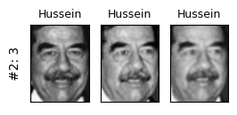

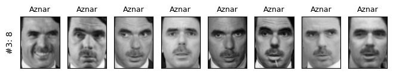

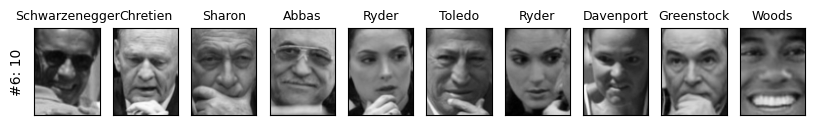

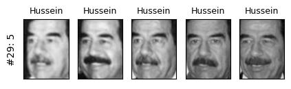

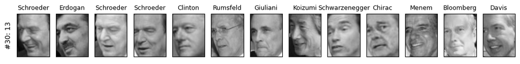

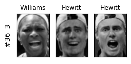

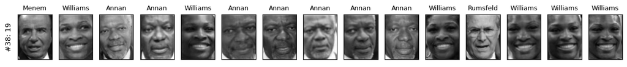

```python
hand_picked_clusters = [2, 3, 6, 29, 30, 36, 38]
print_hierarchical_clusters(
    X_people, y_people, people.target_names, cluster_labels, hand_picked_clusters
)
plt.show()
```

## Final comments, summary, and reflection

### Take-home message

- We saw three methods for clustering: K-Means, DBSCAN, and hierarchical clustering.
- There are many more clustering algorithms out there which we didn't talk about. For example see [this overview of clustering methods](https://scikit-learn.org/stable/modules/clustering.html#overview-of-clustering-methods).
- Two important aspects of clustering
  - Choice of distance metric
  - Data representation
- Choosing the appropriate number of clusters for a given problem is quite hard.
- A lot of manual interpretation is involved in clustering.

### A few comments on clustering evaluation

- If you know the ground truth, you can use metrics such as [adjusted random score](https://scikit-learn.org/stable/modules/generated/sklearn.metrics.adjusted_rand_score.html) or [normalized mutual information score](https://scikit-learn.org/stable/modules/generated/sklearn.metrics.normalized_mutual_info_score.html).
- We can't use accuracy scores.
  - Because the labels themselves are meaningless in clustering.
- Usually ground truth is not available, and if it is available we would probably go with supervised models.
- The silhouette score works for different clustering methods and it can give us some intuition about the quality of clusters. But it's not very interpretable on real-world datasets.

A couple of ways to evaluate clustering:

- Using *robustness-based* clustering metrics
- The idea is to run a clustering algorithm or a number of clustering algorithms after adding some noise to the data or using different parameter settings and comparing outcomes.
- If many models, perturbations, and parameters are giving the same result, the clustering is likely to be trustworthy.
- That said, even though all clustering models give similar results, the clusters might not capture the aspect you are interested in.
- So you cannot really avoid manual analysis!!

## Resources

- Check out this nice comparison of [sklearn clustering algorithms](https://scikit-learn.org/stable/modules/clustering.html#overview-of-clustering-methods).
- [DBSCAN Visualization](https://www.naftaliharris.com/blog/visualizing-dbscan-clustering/)
- [Clustering with Scikit with GIFs](https://dashee87.github.io/data%20science/general/Clustering-with-Scikit-with-GIFs/)